# Los_Angeles_Inspection_EDA

```python
import pandas as pd
import numpy as np
import pickle
import datetime

# Visualisation libraries

## Text
from colorama import Fore, Back, Style
from IPython.display import Image, display, Markdown, Latex, clear_output

## seaborn
import seaborn as sns

## matplotlib
import matplotlib.pyplot as plt
from matplotlib.patches import Ellipse, Polygon
from matplotlib.font_manager import FontProperties
import matplotlib.colors as mcolors
plt.style.use('seaborn-whitegrid')
plt.rcParams['axes.labelsize'] = 14
plt.rcParams['xtick.labelsize'] = 12
plt.rcParams['ytick.labelsize'] = 12
plt.rcParams['text.color'] = 'k'
%matplotlib inline

import warnings
warnings.filterwarnings("ignore")
```

[Home](https://hatefdastour.github.io/) / [Healthcare Analytics and Modeling](https://hatefdastour.github.io/portfolio/healthcare_analytics_and_modeling/)

## Los Angeles County Restaurant and Market Violations and Inspections

- [**Preprocessing**](https://hatefdastour.github.io/portfolio/healthcare_analytics_and_modeling/Los_Angeles_Inspection_Preprocessing.html)
- [**Exploratory Data Analysis**](https://hatefdastour.github.io/portfolio/healthcare_analytics_and_modeling/Los_Angeles_Inspection_EDA.html)
- [**Interactive Maps**](https://hatefdastour.github.io/portfolio/healthcare_analytics_and_modeling/Los_Angeles_Inspection_Maps.html)

**Los Angeles County Restaurant and Market Violations and Inspections**

In this article, we use a dataset contains Environmental Health Violations for Restaurants and Markets in Los Angeles County. This dataset can be found [[1](https://data.lacounty.gov/Health/LOS-ANGELES-COUNTY-RESTAURANT-AND-MARKET-VIOLATION/8jyd-4pv9)] and [[2](https://data.lacounty.gov/Health/LOS-ANGELES-COUNTY-RESTAURANT-AND-MARKET-INSPECTIO/6ni6-h5kp)].

Los Angeles County Environmental Health is responsible for checking food violations for all unincorporated areas and 85 of the 88 cities in the County. This dataset does not include Pasadena, Long Beach or Vernon (each has its own city health department).

## Loading Datasets

```python
Violations_df = pd.read_csv('LA/Clean_Violations_df.csv')
Inspections_df = pd.read_csv('LA/Clean_Inspections_df.csv')
Data  = pd.read_csv('LA/Data_Inspections_Violations_df.csv')

# Dictionaries
with open('LA/vDict.pkl', 'rb') as fp:
    Violation_Dictionary= pickle.load(fp)
```

## Violations Dataset

Each row represents one health code violation. All rows with the same Serial Number are part of the same inspection. The Serial Number is the primary key to review the inspection grade (Inspection Result dataset)

```python
Violations_df.head().style.hide_index()
```

| Serial Number | Violation Status | Violation Code | Violation Description | Points |
| --- | --- | --- | --- | --- |
| DA000211Z | Out Of Compliance | F006 | # 06. Adequate handwashing facilities supplied & accessible | 2.000000 |
| DA000211Z | Out Of Compliance | F044 | # 44. Floors, walls and ceilings: properly built, maintained in good repair and clean | 1.000000 |
| DA000211Z | Out Of Compliance | F014 | # 14. Food contact surfaces: clean and sanitized | 2.000000 |
| DA000211Z | Out Of Compliance | F029 | # 29. Toxic substances properly identified, stored, used | 1.000000 |
| DA000211Z | Out Of Compliance | F035 | # 35. Equipment/Utensils - approved; installed; clean; good repair, capacity | 1.000000 |

## Inspection Result Dataset

Each row represents one inspection result. The Serial Number is the primary key to access/review the violations (Violations Dataset) associated with a particular inspection.

```python
Inspections_df.head().style.hide_index()
```

| Activity Date | Owner ID | Owner Name | Facility ID | Facility Name | Record ID | Program Name | Program Status | Program Element (PE) | PE Description | Facility Address | Facility City | Facility State | Facility Zip | Service Code | Service Description | Score | Serial Number | Employee ID |
| --- | --- | --- | --- | --- | --- | --- | --- | --- | --- | --- | --- | --- | --- | --- | --- | --- | --- | --- |
| 2016-04-18 | OW0025500 | NADAL, MARIA E | FA0050431 | TACOS LOCOS | PR0006119 | TACOS LOCOS | ACTIVE | 1632 | RESTAURANT (0-30) SEATS HIGH RISK | 2148 W VENICE BLVD | LOS ANGELES | CA | 90006 | 1 | ROUTINE INSPECTION | 95 | DAPEK1ZHT | EE0000235 |
| 2016-05-10 | OW0101912 | KORSINJJI, INC. | FA0138571 | GINZAYA | PR0122907 | GINZAYA | ACTIVE | 1635 | RESTAURANT (31-60) SEATS HIGH RISK | 4218 WOODRUFF AVE | LAKEWOOD | CA | 90713 | 1 | ROUTINE INSPECTION | 93 | DA99MMIVM | EE0000145 |
| 2016-05-16 | OW0019985 | KRANIGER MARK | FA0019484 | DOMINO'S PIZZA | PR0046600 | DOMINO'S PIZZA | ACTIVE | 1631 | RESTAURANT (0-30) SEATS MODERATE RISK | 14604 E RAMONA BLVD | BALDWIN PARK | CA | 91706 | 1 | ROUTINE INSPECTION | 99 | DAAEKGSIV | EE0000242 |
| 2016-05-17 | OW0010842 | EL GALLO GIRO CORPORATION | FA0061424 | EL GALLO GIRO | PR0013623 | EL GALLO GIRO (BAKERY) | ACTIVE | 1631 | RESTAURANT (0-30) SEATS MODERATE RISK | 5686 E WHITTIER BLVD | COMMERCE | CA | 90040 | 1 | ROUTINE INSPECTION | 92 | DA6AHXMFB | EE0000557 |
| 2016-05-17 | OW0011145 | ENPORAX, INC | FA0041248 | MONJA | PR0046046 | MONJA | INACTIVE | 1635 | RESTAURANT (31-60) SEATS HIGH RISK | 18558 E GALE AVE STE #108 | ROWLAND HEIGHTS | CA | 91748 | 1 | ROUTINE INSPECTION | 85 | DA2OIE8HS | EE0000487 |

## Merged Dataset

```python
Data.head().style.hide_index()
```

| Activity Date | Owner ID | Owner Name | Facility ID | Facility Name | Record ID | Program Name | Program Status | Program Element (PE) | Facility Address | Facility City | Facility State | Facility Zip | Service Code | Service Description | Score | Serial Number | Employee ID | Violation Status | Violation Code | Violation Description | Points | PE Type | PE Seats | PE Risk |
| --- | --- | --- | --- | --- | --- | --- | --- | --- | --- | --- | --- | --- | --- | --- | --- | --- | --- | --- | --- | --- | --- | --- | --- | --- |
| 2019-06-18 | OW0033887 | ST TROP INC | FA0035660 | SUSHI YA | PR0015355 | SUSHI YA | ACTIVE | 1635.000000 | 8650 W SUNSET BLVD | WEST HOLLYWOOD | CA | 90069.000000 | 1.000000 | ROUTINE INSPECTION | 93.000000 | DA000211Z | EE0000838 | Out Of Compliance | F006 | # 06. Adequate handwashing facilities supplied & accessible | 2.000000 | Restaurant | 31-60 SQ. FT. | Seats High Risk |
| 2019-06-18 | OW0033887 | ST TROP INC | FA0035660 | SUSHI YA | PR0015355 | SUSHI YA | ACTIVE | 1635.000000 | 8650 W SUNSET BLVD | WEST HOLLYWOOD | CA | 90069.000000 | 1.000000 | ROUTINE INSPECTION | 93.000000 | DA000211Z | EE0000838 | Out Of Compliance | F044 | # 44. Floors, walls and ceilings: properly built, maintained in good repair and clean | 1.000000 | Restaurant | 31-60 SQ. FT. | Seats High Risk |
| 2019-06-18 | OW0033887 | ST TROP INC | FA0035660 | SUSHI YA | PR0015355 | SUSHI YA | ACTIVE | 1635.000000 | 8650 W SUNSET BLVD | WEST HOLLYWOOD | CA | 90069.000000 | 1.000000 | ROUTINE INSPECTION | 93.000000 | DA000211Z | EE0000838 | Out Of Compliance | F014 | # 14. Food contact surfaces: clean and sanitized | 2.000000 | Restaurant | 31-60 SQ. FT. | Seats High Risk |
| 2019-06-18 | OW0033887 | ST TROP INC | FA0035660 | SUSHI YA | PR0015355 | SUSHI YA | ACTIVE | 1635.000000 | 8650 W SUNSET BLVD | WEST HOLLYWOOD | CA | 90069.000000 | 1.000000 | ROUTINE INSPECTION | 93.000000 | DA000211Z | EE0000838 | Out Of Compliance | F029 | # 29. Toxic substances properly identified, stored, used | 1.000000 | Restaurant | 31-60 SQ. FT. | Seats High Risk |
| 2019-06-18 | OW0033887 | ST TROP INC | FA0035660 | SUSHI YA | PR0015355 | SUSHI YA | ACTIVE | 1635.000000 | 8650 W SUNSET BLVD | WEST HOLLYWOOD | CA | 90069.000000 | 1.000000 | ROUTINE INSPECTION | 93.000000 | DA000211Z | EE0000838 | Out Of Compliance | F035 | # 35. Equipment/Utensils - approved; installed; clean; good repair, capacity | 1.000000 | Restaurant | 31-60 SQ. FT. | Seats High Risk |

# Exploratory Data Analysis

## Dates with the most Number of Violations

```python
Activity = pd.DataFrame(Data.groupby('Activity Date')['Violation Code'].count())
Activity.columns = ['Count']
Activity[Activity['Count'] >2400 ].T
Temp = Activity[Activity['Count'] == Activity.max()[0]].index[0]
Temp = datetime.datetime.strptime(Temp, '%Y-%m-%d')
print('We can see that the highest number of violations happened on ' + \
      Fore.BLUE + '%s' % '{:%A, %B %d, %Y}'.format(Temp) + Style.RESET_ALL)
del Temp
```

```
We can see that the highest number of violations happened on Wednesday, January 23, 2019
```

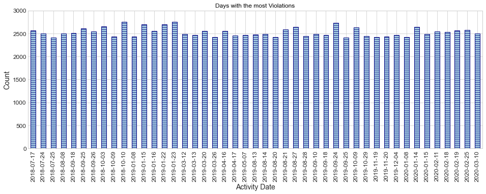

```python
fig, ax = plt.subplots(nrows=1, ncols=1, figsize=(16, 5), sharex=False)
_ = Activity[Activity['Count'] >2400 ].plot.bar(rot=90,ax=ax, legend=False,
                                                color=sns.light_palette('lightBlue', reverse=True), edgecolor='Navy',
                                                hatch = '---')
_ = ax.set_title('Days with the most Violations')
_ = ax.set_ylim([0, 3e3])
_ = ax.set_xlabel('Activity Date')
_ = ax.set_ylabel('Count')
```

In particular, for the hightest number of violations, we have

| Violation Code | F004 | F005 | F006 | F007 | F008 | F009 | F011 | F013 | F014 | F016 | ... | F047 | F048 | F049 | F050 | F052 | F053 | F054 | F055 | F057 | F058 |
| --- | --- | --- | --- | --- | --- | --- | --- | --- | --- | --- | --- | --- | --- | --- | --- | --- | --- | --- | --- | --- | --- |
| Count | 11 | 11 | 115 | 105 | 15 | 27 | 1 | 13 | 114 | 5 | ... | 4 | 23 | 33 | 14 | 35 | 41 | 7 | 21 | 2 | 4 |

1 rows × 45 columns

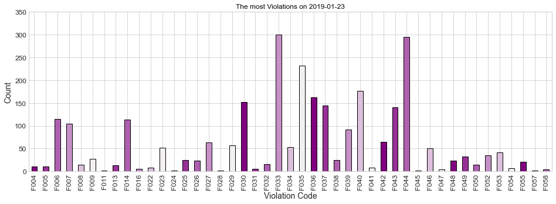

```python
Activity_Violation = pd.DataFrame(Data.groupby(['Activity Date','Violation Code'])['Violation Code'].count())
Activity_Violation.columns = ['Count']
list = Activity[Activity['Count'] == Activity['Count'].max()].index
temp = Activity_Violation.loc[list]
temp = temp.reset_index(drop=False).drop(columns ='Activity Date')
display(temp.set_index(['Violation Code']).T)

fig, ax = plt.subplots(nrows=1, ncols=1, figsize=(16, 5), sharex=False)
_ = temp.plot.bar(rot=90,ax=ax, x='Violation Code', y='Count', legend=False,
                  color=sns.light_palette("purple", reverse=True), edgecolor="k")
_ = ax.set_title('The most Violations on %s' % list.tolist()[0])
_ = ax.set_ylim([0, 350])
# _ = ax.set_yscale('log')
_ = ax.set_xlabel('Violation Code')
_ = ax.set_ylabel('Count')
```

The most violations on this day are:

```python
mylist = temp.sort_values('Count', ascending=False).head(3)['Violation Code'].tolist()
display(pd.DataFrame({'Code':mylist,' Description': [Violation_Dictionary[x] for x in mylist]}).style.hide_index())
del temp
```

| Code | Description |
| --- | --- |
| F033 | # 33. Nonfood-contact surfaces clean and in good repair |
| F044 | # 44. Floors, walls and ceilings: properly built, maintained in good repair and clean |
| F035 | # 35. Equipment/Utensils - approved; installed; clean; good repair, capacity |

## Restaurant Owners with the most number of Violations

| Owner ID | OW0029458 | OW0038181 | OW0033938 | OW0010868 | OW0012108 | OW0004937 | OW0034460 | OW0033717 | OW0007608 | OW0027458 | OW0012926 | OW0038850 |
| --- | --- | --- | --- | --- | --- | --- | --- | --- | --- | --- | --- | --- |
| Count | 6314 | 4472 | 3272 | 2381 | 2173 | 2127 | 2042 | 1997 | 1816 | 1790 | 1735 | 1712 |

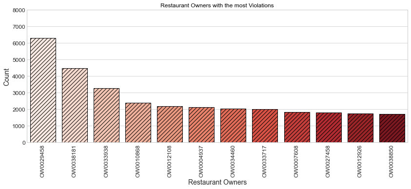

```python
Owners= pd.DataFrame(Data[Data['Owner ID'].isna()==False].groupby('Owner ID')['Violation Code'].count())
Owners.columns = ['Count']
Owners=Owners.sort_values(by='Count', ascending=False)
display(Owners[Owners['Count'] >1.5e3].T)

fig, ax = plt.subplots(nrows=1, ncols=1, figsize=(14, 5), sharex=False)

_ = sns.barplot(ax = ax, x='Owner ID', y='Count', palette='Reds',
                edgecolor='k',  hatch="///", data= Owners[Owners['Count'] >1.5e3].reset_index())
# _ = Owners[Owners['Count'] >1.5e3].plot.bar(rot=90,ax=ax, legend=False, color="#34495e", edgecolor="k")
_ = ax.set_xticklabels(ax.get_xticklabels(), rotation=90)
_ = ax.set_title('Restaurant Owners with the most Violations')
_ = ax.set_ylim([0, 8e3])
_ = ax.set_xlabel('Restaurant Owners')
_ = ax.set_ylabel('Count')
```

In particular,

| Violation Code | F004 | F005 | F006 | F007 | F008 | F009 | F011 | F013 | F014 | F016 | ... | F046 | F047 | F048 | F049 | F050 | F052 | F053 | F054 | F055 | F058 |
| --- | --- | --- | --- | --- | --- | --- | --- | --- | --- | --- | --- | --- | --- | --- | --- | --- | --- | --- | --- | --- | --- |
| Count | 5 | 12 | 193 | 232 | 9 | 3 | 2 | 21 | 130 | 20 | ... | 88 | 2 | 29 | 68 | 7 | 24 | 64 | 2 | 22 | 7 |

1 rows × 42 columns

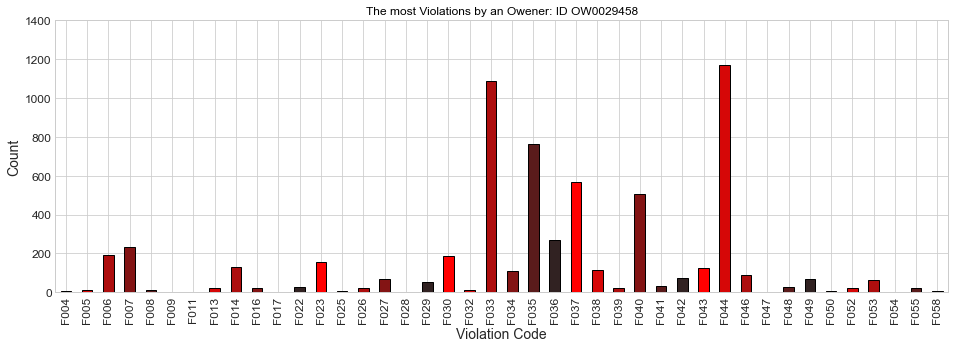

```python
Owners_Violation  = pd.DataFrame(Data.groupby(['Owner ID','Violation Code'])['Violation Code'].count())
Owners_Violation.columns = ['Count']
list = Owners[Owners['Count'] == Owners['Count'].max()].index
temp = Owners_Violation.loc[list]
temp = temp.reset_index(drop=False).drop(columns ='Owner ID')
display(temp.set_index(['Violation Code']).T)

fig, ax = plt.subplots(nrows=1, ncols=1, figsize=(16, 5), sharex=False)
_ = temp.plot.bar(rot=90,ax=ax, x='Violation Code', y='Count', legend=False,
                  color=sns.dark_palette("red", reverse=True), edgecolor="k")
_ = ax.set_title('The most Violations by an Owener: ID %s' % list.tolist()[0])
_ = ax.set_ylim([0, 1.4e3])
_ = ax.set_xlabel('Violation Code')
_ = ax.set_ylabel('Count')
```

The most violations by this owner are:

```python
mylist=temp.sort_values('Count', ascending=False).head(3)['Violation Code'].tolist()
display(pd.DataFrame({'Code':mylist,' Description': [Violation_Dictionary[x] for x in mylist]}).style.hide_index())
```

| Code | Description |
| --- | --- |
| F044 | # 44. Floors, walls and ceilings: properly built, maintained in good repair and clean |
| F033 | # 33. Nonfood-contact surfaces clean and in good repair |
| F035 | # 35. Equipment/Utensils - approved; installed; clean; good repair, capacity |

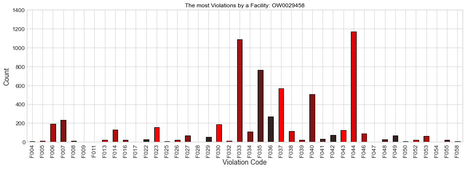

```python
fig, ax = plt.subplots(nrows=1, ncols=1, figsize=(16, 5), sharex=False)
_ = temp.plot.bar(rot=90,ax=ax, x='Violation Code', y='Count', legend=False,
                  color=sns.dark_palette("red", reverse=True), edgecolor="k")
_ = ax.set_title('The most Violations by a Facility: %s' % list.tolist()[0])
_ = ax.set_ylim([0, 1400])
_ = ax.set_xlabel('Violation Code')
_ = ax.set_ylabel('Count')
```

```python
mylist=temp.sort_values('Count', ascending=False).head(3)['Violation Code'].tolist()
display(pd.DataFrame({'Code':mylist,' Description': [Violation_Dictionary[x] for x in mylist]}).style.hide_index())
```

| Code | Description |
| --- | --- |
| F044 | # 44. Floors, walls and ceilings: properly built, maintained in good repair and clean |
| F033 | # 33. Nonfood-contact surfaces clean and in good repair |
| F035 | # 35. Equipment/Utensils - approved; installed; clean; good repair, capacity |

## Programs with the Most Violations

| Program Name | SUBWAY | WABA GRILL | EL POLLO LOCO | DOMINO'S PIZZA | JERSEY MIKE'S SUBS | JACK IN THE BOX | MCDONALD'S | 7-ELEVEN | THE FLAME BROILER | ONO HAWAIIAN BBQ |
| --- | --- | --- | --- | --- | --- | --- | --- | --- | --- | --- |
| Count | 1725 | 1365 | 1259 | 1198 | 1174 | 1016 | 917 | 851 | 833 | 808 |

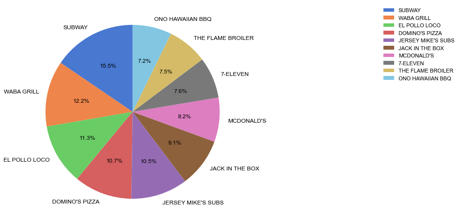

```python
Programs = pd.DataFrame(Data[Data['Program Name'].isna()==False].groupby('Program Name')['Violation Code'].count())
Programs.columns = ['Count']
Programs.sort_values(by='Count', ascending=False, inplace = True)
display(Programs[Programs['Count'] >8e2].T)

fig, ax = plt.subplots(1,1, figsize=(8,10))
_ = Programs[Programs['Count'] >8e2].plot.pie(y='Count', startangle=90, legend=False,label='',ax=ax, autopct='%1.1f%%',
                   colors = sns.color_palette("muted", len(Programs[Programs['Count'] >8e2])), fontsize=12)
_ = ax.legend(bbox_to_anchor=(2, 1), fontsize=11)
```

| Violation Code | F004 | F005 | F006 | F007 | F008 | F009 | F011 | F013 | F014 | F022 | ... | F043 | F044 | F046 | F048 | F049 | F050 | F052 | F053 | F054 | F055 |
| --- | --- | --- | --- | --- | --- | --- | --- | --- | --- | --- | --- | --- | --- | --- | --- | --- | --- | --- | --- | --- | --- |
| Count | 9 | 13 | 45 | 154 | 1 | 3 | 1 | 2 | 108 | 4 | ... | 74 | 233 | 78 | 19 | 25 | 3 | 57 | 23 | 2 | 11 |

1 rows × 37 columns

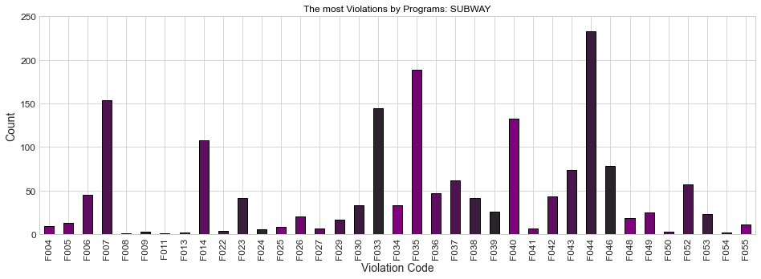

```python
Programs_Violation  = pd.DataFrame(Data.groupby(['Program Name','Violation Code'])['Violation Code'].count())
Programs_Violation.columns = ['Count']

list = Programs[Programs['Count'] == Programs['Count'].max()].index
temp = Programs_Violation.loc[list]
temp = temp.reset_index(drop=False).drop(columns ='Program Name')
display(temp.set_index(['Violation Code']).T)

fig, ax = plt.subplots(nrows=1, ncols=1, figsize=(16, 5), sharex=False)
_ = temp.plot.bar(rot=90,ax=ax, x='Violation Code', y='Count', legend=False,
                  color=sns.dark_palette("purple", reverse=True), edgecolor="k")
_ = ax.set_title('The most Violations by Programs: %s' % list.tolist()[0])
_ = ax.set_ylim([0, 2.5e2])
_ = ax.set_xlabel('Violation Code')
_ = ax.set_ylabel('Count')
```

```python
mylist=temp.sort_values('Count', ascending=False).head(3)['Violation Code'].tolist()
display(pd.DataFrame({'Code':mylist,' Description': [Violation_Dictionary[x] for x in mylist]}).style.hide_index())
```

| Code | Description |
| --- | --- |
| F044 | # 44. Floors, walls and ceilings: properly built, maintained in good repair and clean |
| F035 | # 35. Equipment/Utensils - approved; installed; clean; good repair, capacity |
| F007 | # 07. Proper hot and cold holding temperatures |

## Cities with the Most Violations

|  | LOS ANGELES | TORRANCE | GLENDALE | SANTA MONICA | NORTH HOLLYWOOD | GARDENA | VAN NUYS | BURBANK | WHITTIER | INGLEWOOD | ... | VENICE | HACIENDA HEIGHTS | GRANADA HILLS | AZUSA | SOUTH EL MONTE | WILMINGTON | CLAREMONT | GLENDORA | DIAMOND BAR | NORTH HILLS |
| --- | --- | --- | --- | --- | --- | --- | --- | --- | --- | --- | --- | --- | --- | --- | --- | --- | --- | --- | --- | --- | --- |
| Count | 237151 | 20609 | 19024 | 14623 | 14300 | 13185 | 12758 | 12612 | 11478 | 11446 | ... | 3613 | 3606 | 3575 | 3566 | 3307 | 3156 | 3143 | 3108 | 3103 | 3003 |

1 rows × 75 columns

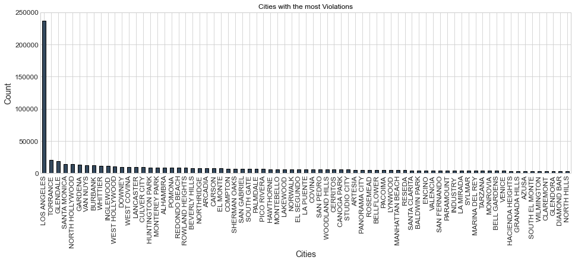

```python
Facility_Cities = pd.DataFrame(Data[Data['Facility City'].isna()==False].groupby('Facility City')['Violation Code'].count())
Facility_Cities.columns = ['Count']
Facility_Cities=Facility_Cities.sort_values(by='Count', ascending=False)
list = Facility_Cities.index.tolist()
Facility_Cities.index = list
display(Facility_Cities[Facility_Cities['Count'] >3e3].T)

fig, ax = plt.subplots(nrows=1, ncols=1, figsize=(16, 5), sharex=False)
_ = Facility_Cities[Facility_Cities['Count'] >3e3].plot.bar(ax=ax, legend=False, color='#34495e', edgecolor='k')
_ = ax.set_title('Cities with the most Violations')
_ = ax.set_ylim([0, 2.5e5])
_ = ax.set_xlabel('Cities')
_ = ax.set_ylabel('Count')
# _ = ax.set_xticklabels(labels = [x.title() for x in list],rotation=90)
```

| Violation Code | CV20 | CV29 | CV30 | F002 | F003 | F004 | F005 | F006 | F007 | F008 | ... | W023 | W024 | W031 | W034 | W041 | W044 | W048 | W051 | W052 | W053 |
| --- | --- | --- | --- | --- | --- | --- | --- | --- | --- | --- | --- | --- | --- | --- | --- | --- | --- | --- | --- | --- | --- |
| Count | 2 | 3 | 1 | 4 | 7 | 712 | 1068 | 10046 | 8830 | 1307 | ... | 4 | 1 | 1 | 2 | 1 | 1 | 1 | 1 | 4 | 1 |

1 rows × 69 columns

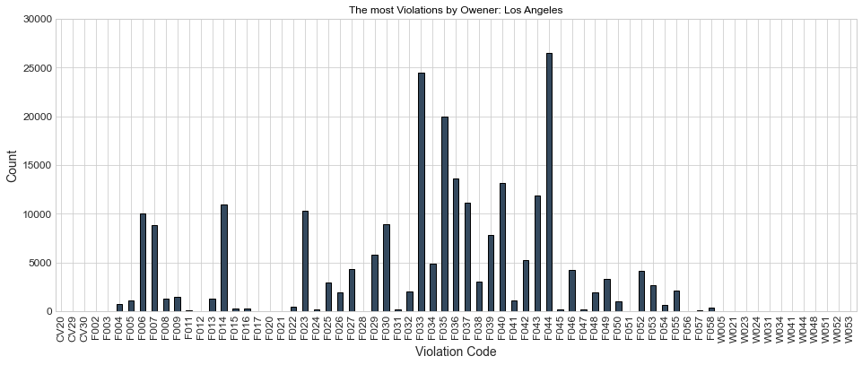

```python
Facility_Cities_Violation  = pd.DataFrame(Data.groupby(['Facility City','Violation Code'])['Violation Code'].count())
Facility_Cities_Violation.columns = ['Count']

list = Facility_Cities[Facility_Cities['Count'] == Facility_Cities['Count'].max()].index
temp = Facility_Cities_Violation.loc[list]
temp = temp.reset_index(drop=False).drop(columns ='Facility City').set_index(['Violation Code'])
display(temp.T)

fig, ax = plt.subplots(nrows=1, ncols=1, figsize=(16, 6), sharex=False)
_ = temp.plot.bar(rot=90,ax=ax, legend=False, color='#34495e', edgecolor='k')
_ = ax.set_title('The most Violations by Owener: %s' % list.tolist()[0].title())
_ = ax.set_ylim([0, 3e4])
_ = ax.set_xlabel('Violation Code')
_ = ax.set_ylabel('Count')
```

The most violations by this city are:

```python
mylist=temp.sort_values('Count', ascending=False).head(3).index.tolist()
display(pd.DataFrame({'Code':mylist,' Description': [Violation_Dictionary[x] for x in mylist]}).style.hide_index())
```

| Code | Description |
| --- | --- |
| F044 | # 44. Floors, walls and ceilings: properly built, maintained in good repair and clean |
| F033 | # 33. Nonfood-contact surfaces clean and in good repair |
| F035 | # 35. Equipment/Utensils - approved; installed; clean; good repair, capacity |

## Service Description

```python
Service_Description = pd.DataFrame(Data[Data['Service Description'].isna()==False].groupby('Service Description')['Violation Code'].count())
Service_Description.columns = ['Count']
Service_Description.index = [x.title() for x in Service_Description.index.tolist()]
Service_Description
```

|  | Count |
| --- | --- |
| Owner Initiated Inspection | 11447 |
| Routine Inspection | 817809 |

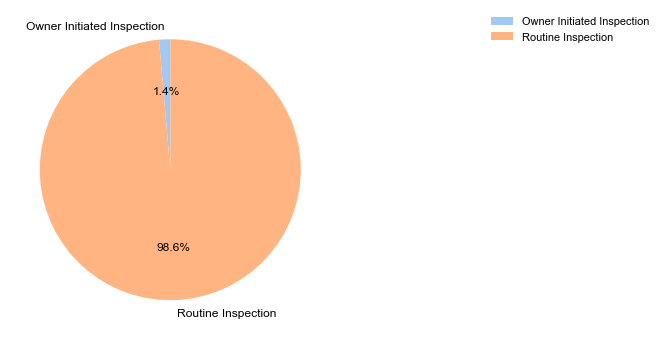

```python
fig, ax = plt.subplots(1,1, figsize=(14,6))
_ = Service_Description.plot.pie(y='Count', startangle=90, legend=False,label='',ax=ax, autopct='%1.1f%%',
                   colors = sns.color_palette("pastel", len(Programs[Programs['Count'] >8e2])), fontsize=12)
_ = ax.legend(bbox_to_anchor=(2, 1), fontsize=11)
```

| Violation Code | CV11 | CV15 | CV20 | CV23 | CV25 | CV27 | CV29 | CV30 | CV31 | CV45 | ... | W030 | W031 | W034 | W041 | W044 | W048 | W050 | W051 | W052 | W053 |
| --- | --- | --- | --- | --- | --- | --- | --- | --- | --- | --- | --- | --- | --- | --- | --- | --- | --- | --- | --- | --- | --- |
| Count | 1 | 1 | 2 | 1 | 1 | 1 | 4 | 3 | 1 | 1 | ... | 1 | 3 | 4 | 1 | 1 | 2 | 1 | 7 | 7 | 1 |

1 rows × 89 columns

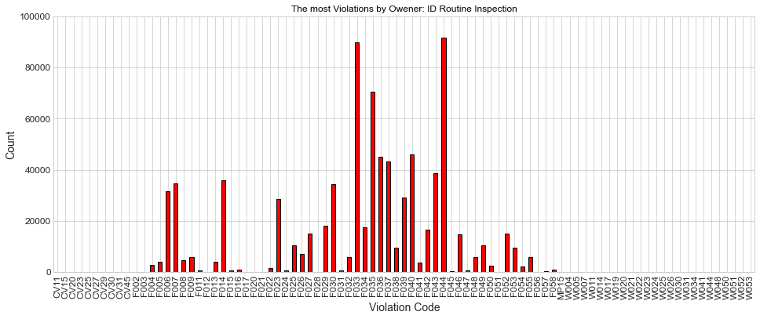

```python
Service_Description_Violation = pd.DataFrame(Data.groupby(['Service Description','Violation Code'])['Violation Code'].count())
Service_Description_Violation.columns = ['Count']
list = Service_Description[Service_Description['Count'] == Service_Description['Count'].max()].index
temp = Service_Description_Violation.loc[list[0].upper()]
display(temp.T)

fig, ax = plt.subplots(nrows=1, ncols=1, figsize=(16, 6), sharex=False)
_ = temp.plot.bar(rot=90,ax=ax, legend=False, color=sns.dark_palette("red", reverse=True), edgecolor="k")
_ = ax.set_title('The most Violations by Owener: ID %s' % list.tolist()[0])
_ = ax.set_ylim([0, 1e5])
_ = ax.set_xlabel('Violation Code')
_ = ax.set_ylabel('Count')
```

```python
mylist=temp.sort_values('Count', ascending=False).head(3).index.tolist()
display(pd.DataFrame({'Code':mylist,' Description': [Violation_Dictionary[x] for x in mylist]}).style.hide_index())
```

| Code | Description |
| --- | --- |
| F044 | # 44. Floors, walls and ceilings: properly built, maintained in good repair and clean |
| F033 | # 33. Nonfood-contact surfaces clean and in good repair |
| F035 | # 35. Equipment/Utensils - approved; installed; clean; good repair, capacity |

## The Number of Violations by High-Score and Low-Score Facilities

```python
Score  = pd.DataFrame(Data.groupby(['Score','Facility Name'])['Violation Code'].count())
Score.columns = ['Count']
Score = Score.reset_index()
Score.head(10).style.hide_index()
```

| Score | Facility Name | Count |
| --- | --- | --- |
| 3.000000 | BIONICOS EXPRESS | 2 |
| 52.000000 | HOKKAIDO SEAFOOD BUFFET | 14 |
| 54.000000 | BYBY'S BAKERY | 19 |
| 58.000000 | LIQUORAMA | 9 |
| 59.000000 | NEW KYOTO SUSHI | 22 |
| 60.000000 | EILAT BAKERY | 21 |
| 60.000000 | ESTRADA AND SONS PRODUCE | 16 |
| 60.000000 | GUTIERREZ MARKET INC | 10 |
| 60.000000 | JJ'S BAR & GRILL | 16 |
| 61.000000 | GOTKOSHER | 24 |

```python
Score.tail().style.hide_index()
```

| Score | Facility Name | Count |
| --- | --- | --- |
| 100.000000 | TINY GIANT CONVENIENT STORE | 1 |
| 100.000000 | TRUE FOOD KITCHEN | 1 |
| 100.000000 | WOON | 2 |
| 100.000000 | YAMIBUY.COM | 2 |
| 100.000000 | YOSHINOYA #2129 | 1 |

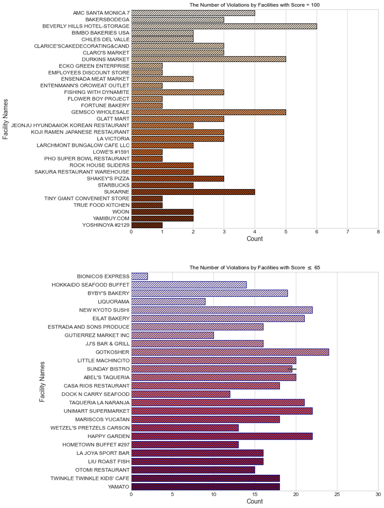

```python
fig, ax = plt.subplots(nrows=2, ncols=1, figsize=(10, 20), sharex = False)
_ = sns.barplot(ax = ax[0], y='Facility Name', x='Count', palette='Oranges',
                edgecolor='k',  hatch="/////", data = Score[Score['Score'] == Score['Score'].max()])
_ = ax[0].set_title('The Number of Violations by Facilities with Score = %i' % Score['Score'].max())
_ = ax[0].set_xlim([0, 8])
_ = ax[0].set_ylabel('Facility Names')
_ = ax[0].set_xlabel('Count')

min_score = 65
_ = sns.barplot(ax = ax[1], y='Facility Name', x='Count', palette='Reds',
                edgecolor='Navy',  hatch="/////", data= Score[Score['Score'] <= min_score])
_ = ax[1].set_title('The Number of Violations by Facilities with Score $\leq$ %i' % min_score)
_ = ax[1].set_xlim([0, 30])
_ = ax[1].set_ylabel('Facility Names')
_ = ax[1].set_xlabel('Count')

# plt.subplots_adjust(hspace=0.2)
```

```python
# Grade  = pd.DataFrame(Data.groupby(['Grade'])['Violation Code'].count())
# Grade.columns = ['Count']
# Grade = Grade.reset_index()
# display(Grade.head().style.hide_index())

# _ = Grade.plot.pie(x='Grade', y='Count', labels=Grade.Grade, startangle=90, legend=False, label='',
#                    figsize=(6,6), autopct='%1.1f%%', fontsize=12)
```

## Violation Status

```python
Violation_Status = pd.DataFrame(Data.groupby('Violation Status')['Violation Code'].count())
Violation_Status.columns = ['Count']
Violation_Status.T
```

| Violation Status | Out Of Compliance | Violation |
| --- | --- | --- |
| Count | 829457 | 1 |

## The Most Described Violations

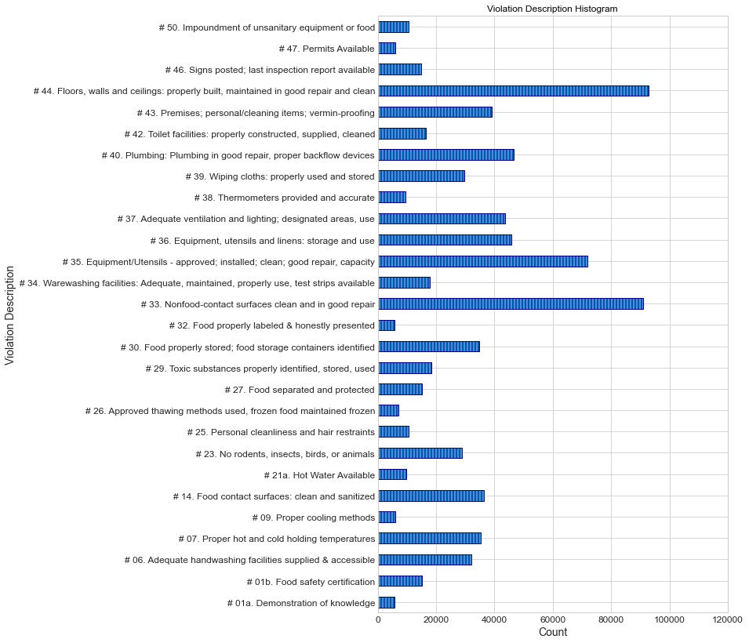

```python
Violation_Description = pd.DataFrame(Data.groupby('Violation Description')['Violation Code'].count())
Violation_Description.columns = ['Count']
# Violation_Description[Violation_Description['Count'] > 5e3]

fig, ax = plt.subplots(nrows=1, ncols=1, figsize=(8, 14), sharex=False)
_ = Violation_Description[Violation_Description['Count'] > 5e3].plot.barh(rot=0, legend=False,
                                                         ax=ax, color='#3498db', edgecolor='Navy', hatch = '|||')
_ = ax.set_title('Violation Description Histogram')
_ = ax.set_xlim([0, 1.2e5])
_ = ax.set_xlabel('Count')
_ = ax.set_ylabel('Violation Description')
```

## Program Element Description

| PE Type | Caterer | Food Mkt Retail | Food Processing Wholesale | Food Vehicle Commissary | Food Warehouse | Interim Housing FF | LIC HTH Care Food FAC | Private School Cafeteria | Restaurant | Skc Tenant Retail Food Operator | Wholesale Food Complex |
| --- | --- | --- | --- | --- | --- | --- | --- | --- | --- | --- | --- |
| Count | 64 | 130556 | 25 | 3 | 3 | 62 | 2 | 14 | 698500 | 3 | 24 |

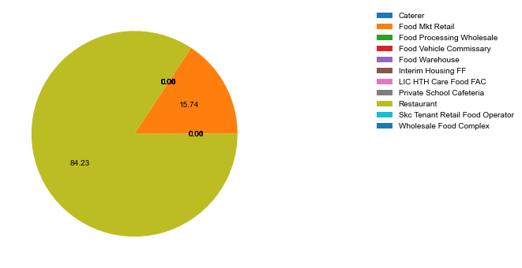

```python
PE_Description_Type = pd.DataFrame(Data.groupby('PE Type')['Violation Code'].count())
PE_Description_Type.columns = ['Count']
display(PE_Description_Type.T)

fig, ax = plt.subplots(1,1, figsize=(14, 6))
_ = patches, text, _ = ax.pie(PE_Description_Type['Count'].values, autopct='%.2f')
_ = ax.legend(patches, labels=PE_Description_Type.index, bbox_to_anchor=(2, 1))
```

| PE Risk | High Risk | Low Risk | Moderate Risk | None | Seats High Risk | Seats Low Risk | Seats Moderate Risk |
| --- | --- | --- | --- | --- | --- | --- | --- |
| Count | 47580 | 71290 | 11688 | 400 | 519923 | 20897 | 157680 |

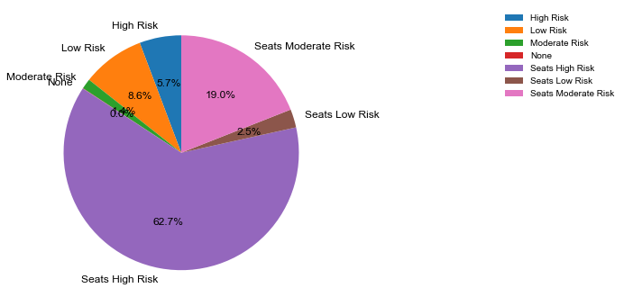

```python
PE_Description_Risk = pd.DataFrame(Data.groupby('PE Risk')['Violation Code'].count())
PE_Description_Risk.columns = ['Count']
display(PE_Description_Risk.T)

fig, ax = plt.subplots(nrows=1, ncols=1, figsize=(6, 6), sharex=False)
_ = PE_Description_Risk.plot.pie(y='Count', startangle=90, legend=False,
                                 label='',ax=ax, autopct='%1.1f%%', fontsize=12)
_ = ax.legend(bbox_to_anchor=(2, 1))
```

| PE Seats | 0-10 SQ. FT. | 0-30 SQ. FT. | 0-999 SQ. FT. | 1-1999 SQ. FT. | 1-4999 SQ. FT. | 1000-1999 SQ. FT. | 10000+ SQ. FT. | 151+ SQ. FT. | 2000+ SQ. FT. | 2000-4999 SQ. FT. | 2000-5999 SQ. FT. | 31-60 SQ. FT. | 6000+ SQ. FT. | 61-150 | ANNUAL | Other |
| --- | --- | --- | --- | --- | --- | --- | --- | --- | --- | --- | --- | --- | --- | --- | --- | --- |
| Count | 3 | 327129 | 34 | 90419 | 3 | 30 | 2 | 49477 | 40189 | 15 | 12 | 182477 | 8 | 139417 | 3 | 240 |

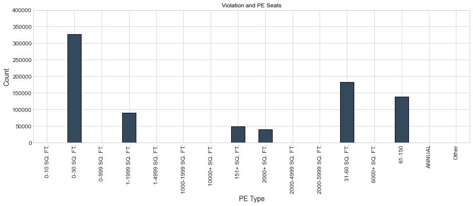

```python
PE_Description_Seats = pd.DataFrame(Data.groupby('PE Seats')['Violation Code'].count())
PE_Description_Seats.columns = ['Count']
display(PE_Description_Seats.T)

fig, ax = plt.subplots(nrows=1, ncols=1, figsize=(16, 5), sharex=False)
_ = PE_Description_Seats.plot.bar(rot=90, legend=False,ax=ax, color="#34495e", edgecolor="k")
_ = ax.set_title('Violation and PE Seats')
_ = ax.set_ylim([0, 4e5])
_ = ax.set_xlabel('PE Type')
_ = ax.set_ylabel('Count')
```

## A Deeper look into Violation by each Facility

We can create a new data frame that represents all the different violations and the total number of each violation.

```python
Violations_by_Facility  = pd.DataFrame(Data.groupby(['Facility ID','Violation Code'])['Violation Code'].count())
Violations_by_Facility.columns = ['Count']
```

Furthermore, we can create a matrix for violations.

```python
Violations_matrix = Violations_by_Facility['Count'].unstack(0).T
Violations_matrix.fillna(0, inplace=True)
Violations_matrix.reset_index(inplace=True)
Violations_matrix.iloc[:,1:] = Violations_matrix.iloc[:,1:].astype('int32')
display(Violations_matrix.head())
## Saving
Violations_matrix.to_csv('LA/Violations_matrix_df.csv',index=False)
```

| Violation Code | Facility ID | F006 | F022 | F023 | F029 | F035 | F036 | F040 | F042 | F044 | ... | W048 | W004 | CV23 | CV25 | CV45 | W050 | CV20 | CV15 | W007 | W053 |
| --- | --- | --- | --- | --- | --- | --- | --- | --- | --- | --- | --- | --- | --- | --- | --- | --- | --- | --- | --- | --- | --- |
| 0 | FA0000968 | 1 | 1 | 1 | 1 | 2 | 3 | 1 | 1 | 3 | ... | 0 | 0 | 0 | 0 | 0 | 0 | 0 | 0 | 0 | 0 |
| 1 | FA0000999 | 0 | 0 | 1 | 0 | 0 | 0 | 2 | 0 | 1 | ... | 0 | 0 | 0 | 0 | 0 | 0 | 0 | 0 | 0 | 0 |
| 2 | FA0001114 | 1 | 0 | 0 | 0 | 2 | 5 | 5 | 1 | 8 | ... | 0 | 0 | 0 | 0 | 0 | 0 | 0 | 0 | 0 | 0 |
| 3 | FA0001155 | 1 | 0 | 0 | 0 | 0 | 0 | 1 | 0 | 0 | ... | 0 | 0 | 0 | 0 | 0 | 0 | 0 | 0 | 0 | 0 |
| 4 | FA0001156 | 0 | 0 | 2 | 0 | 2 | 1 | 1 | 0 | 2 | ... | 0 | 0 | 0 | 0 | 0 | 0 | 0 | 0 | 0 | 0 |

5 rows × 90 columns

Now, we would like to know which one of these violation codes are the most correlated ones.

```python
def Correlation_Plot (Df,Fig_Size):
    Correlation_Matrix = Df.corr()
    mask = np.zeros_like(Correlation_Matrix)
    mask[np.triu_indices_from(mask)] = True
    for i in range(len(mask)):
        mask[i,i]=0
    Fig, ax = plt.subplots(figsize=(Fig_Size,Fig_Size))
    sns.heatmap(Correlation_Matrix, ax=ax, mask=mask, annot=False, square=True,
                cmap =sns.color_palette("RdYlGn", n_colors=10), linewidths = 0.01, vmin=0, vmax=1, cbar_kws={"shrink": .5})
    bottom, top = ax.get_ylim()
```

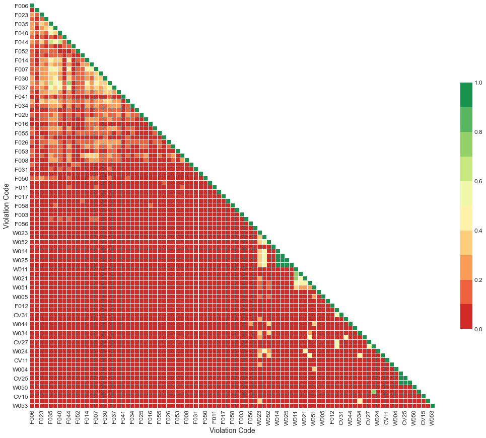

```python
Correlation_Plot(Violations_matrix, 18)
```

Let's consider those with a correlation of at least 0.6.

```python
threshold = 0.6
Correlation_Matrix = Violations_matrix.corr()
mylist=Correlation_Matrix.index.tolist()
new_list=[]
for i in mylist:
    for j in mylist:
        if (Correlation_Matrix.loc[[i],[j]].values[0,0]>=threshold) & (Correlation_Matrix.loc[[i],[j]].values[0,0]!=1):
            new_list.append(i)
            new_list.append(j)
```

```python
del list
mylist=list(set(new_list))
```

Therefore,

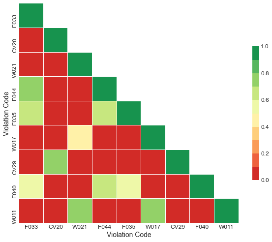

```python
Correlation_Plot(Violations_matrix[mylist], 10)
```

The most correlated codes are:

```python
def List_Print(Text, List, C = 'Blue', T = 'White'):
    BACK = {'Black': Back.BLACK, 'Red':Back.RED, 'Green':Back.GREEN, 'Yellow': Back.YELLOW, 'Blue': Back.BLUE,
            'Magenta':Back.MAGENTA, 'Cyan': Back.CYAN}
    FORE = {'Black': Fore.BLACK, 'Red':Fore.RED, 'Green':Fore.GREEN, 'Yellow':Fore.YELLOW, 'Blue':Fore.BLUE,
            'Magenta':Fore.MAGENTA, 'Cyan':Fore.CYAN, 'White': Fore.WHITE}
    print(BACK[C] + FORE[T] + Style.NORMAL + '%s:' % Text + Style.RESET_ALL + ' %s' % ', '.join(List))
List_Print('The most correlated codes are:', mylist)
```

```
The most correlated codes are:: F033, CV20, W021, F044, F035, W017, CV29, F040, W011
```

# References

1. [LAC Open Data: County of Los Angeles Restaurant and Market Violations](https://data.lacounty.gov/Health/COUNTY-OF-LOS-ANGELES-RESTAURANT-AND-MARKET-VIOLAT/8jyd-4pv9)
2. [LAC Open Data: County of Los Angeles Restaurant and Market Inspections](https://data.lacounty.gov/Health/COUNTY-OF-LOS-ANGELES-RESTAURANT-AND-MARKET-INSPEC/6ni6-h5kp)